# HW3 Template

September 20, 2016

Load required libraries

```r
library(lavaan)
library(semPlot)
```

## Ex A

1. Assign the summarized data to a character vector

```r
# Exercise and weight loss

exercise_lower <- '
   1.0
  .16      1.0,
  .24,    -.43,    1.0,
  .31,     .05,    .07,    1.0 '

# Sample size
N1 <- 767
```

2. Convert to a full symmetric covariance/correlation matrix with names

```r
exercise_cor <- getCov(exercise_lower,
                       names = c("exercise",
                                 "food",
                                 "wt_loss",
                                 "attitude"))
```

3. Specify model

```r
exercise_model <- '
   # regressions
     exercise ~ attitude
     food ~ exercise
     wt_loss ~ exercise + food '
```

4. fit the model

```r
exercise_model_fit <- sem(exercise_model,
           sample.cov = exercise_cor,
           sample.nobs = N1)
```

5. Print a summary of the model estimates and print the standardized solution

```r
summary(exercise_model_fit,
        standardized = TRUE)
```

```
lavaan (0.5-21) converged normally after  14 iterations

  Number of observations                           767

  Estimator                                         ML
  Minimum Function Test Statistic                0.021
  Degrees of freedom                                 2
  P-value (Chi-square)                           0.990

Parameter Estimates:

  Information                                 Expected
  Standard Errors                             Standard

Regressions:
                   Estimate  Std.Err  z-value  P(>|z|)   Std.lv  Std.all
  exercise ~
    attitude          0.310    0.034    9.030    0.000    0.310    0.310
  food ~
    exercise          0.160    0.036    4.489    0.000    0.160    0.160
  wt_loss ~
    exercise          0.317    0.031   10.230    0.000    0.317    0.317
    food             -0.481    0.031  -15.517    0.000   -0.481   -0.481

Variances:
                   Estimate  Std.Err  z-value  P(>|z|)   Std.lv  Std.all
   .exercise          0.903    0.046   19.583    0.000    0.903    0.904
   .food              0.973    0.050   19.583    0.000    0.973    0.974
   .wt_loss           0.716    0.037   19.583    0.000    0.716    0.717
```

6.Plot the path diagram

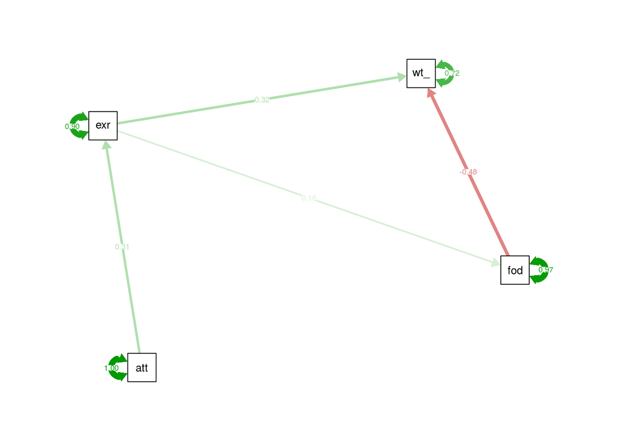

```r
semPaths(exercise_model_fit,
         "par",
         style = "ram",
         layout = "spring")
```